### TD1

*realiser par : Krimi ibrahim*

*Ex1:*

Par exemple pour la loi binomiale, on a :

n <- 20 p <- 0.3 bin <- rbinom(1000, n, p)

La variable bin contient un vecteur de 1000 entiers entre 0 et 20 inclus. Chaque entier correspond à une expérience binomiale B(20, 0.3) : répéter 20 fois une expérience de Bernoulli qui a une chance de succès de 30% et de compter le nombre de succès. La commande plot(bin) affiche graphiquement chacune des 1000 valeurs, dans l’ordre dans lequel elles ont été tirées.

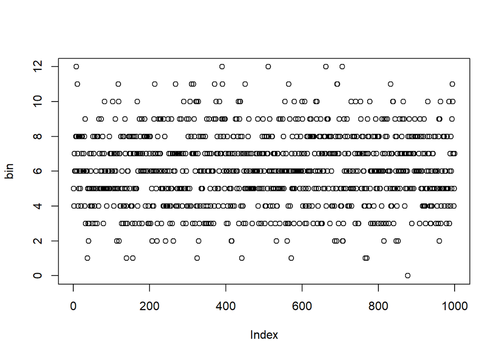

```r
n<-20
p<-0.3
bin<-rbinom(1000,n,p)
plot(bin,type="p")
```

1. Comment connaître le nombre de fois où l’entier 5 apparaît dans le vecteur ?

```r
x<-bin[bin == 5]
length(x)
```

```
## [1] 172
```

2. Comment afficher le tableau donnant l’effectif de chaque modalité ?

```r
table(bin)
```

```
## bin
##   0   1   2   3   4   5   6   7   8   9  10  11  12
##   1   8  20  83 106 172 192 170 127  71  31  14   5
```

3. Comment calculer la moyenne et l’écart type du vecteur bin ? Est-ce loin de l’espérance et de l’écart-type

```r
mean(bin)
```

```
## [1] 6.102
```

```r
sd(bin)
```

```
## [1] 2.058114
```

```r
sqrt(n*p*(1-p))
```

```
## [1] 2.04939
```

4. Affichez l’histogramme de bin

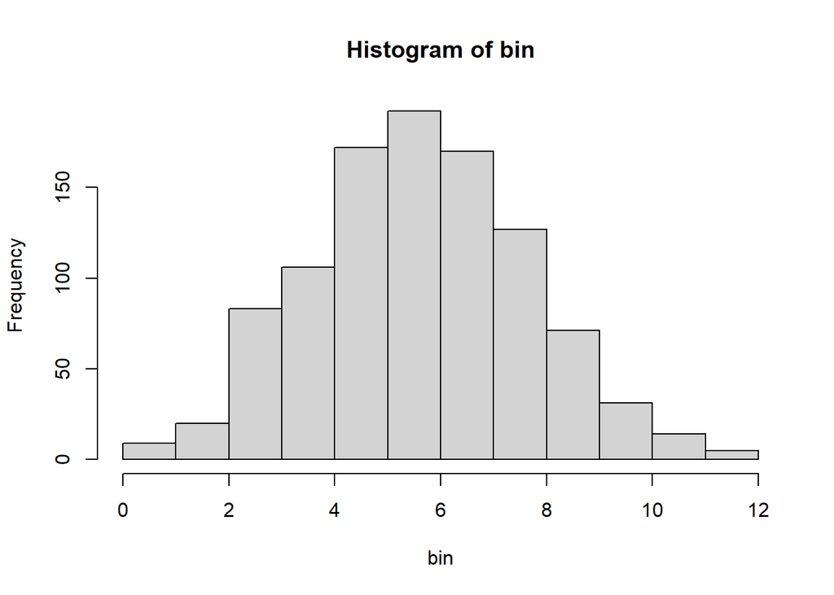

```r
hist(bin)
```

```r
dbinom(5,n,p)
```

```
## [1] 0.1788631
```

```r
dbinom(6,n,p)
```

```
## [1] 0.191639
```

```r
dbinom(7,n,p)
```

```
## [1] 0.164262
```

```r
length(bin[bin == 5])/1000
```

```
## [1] 0.172
```

```r
length(bin[bin == 6])/1000
```

```
## [1] 0.192
```

```r
length(bin[bin == 7])/1000
```

```
## [1] 0.17
```

#remarque:les resultat ne sont pas identique mais proche #

6. Vérifiez que les résultats sont justes avec la formule de la loi binomiale (choose donne les coefficients binomiaux)

```r
k<-c(5,6,7)
choose(n,k)*p**k*(1-p)**(n-k)
```

```
## [1] 0.1788631 0.1916390 0.1642620
```

7. Affichez dans un diagramme en baton, la loi B(20, 0.3)

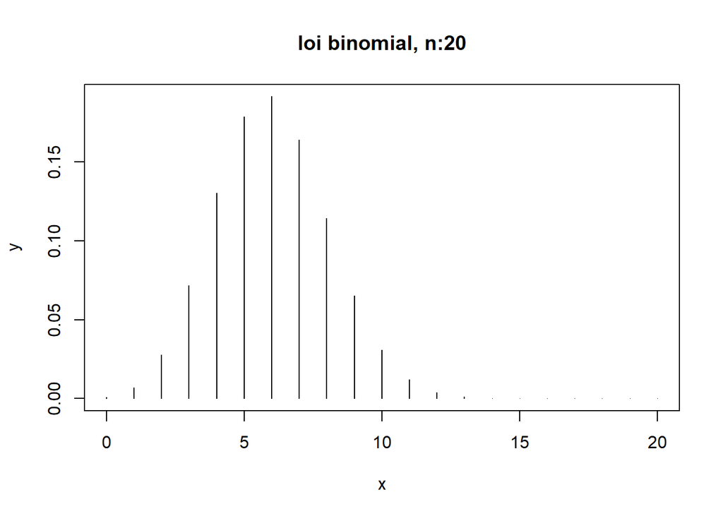

```r
x<-seq(0,20)
y<-dbinom(x,n,p)
plot(x,y,type="h",main="loi binomial, n:20")
```

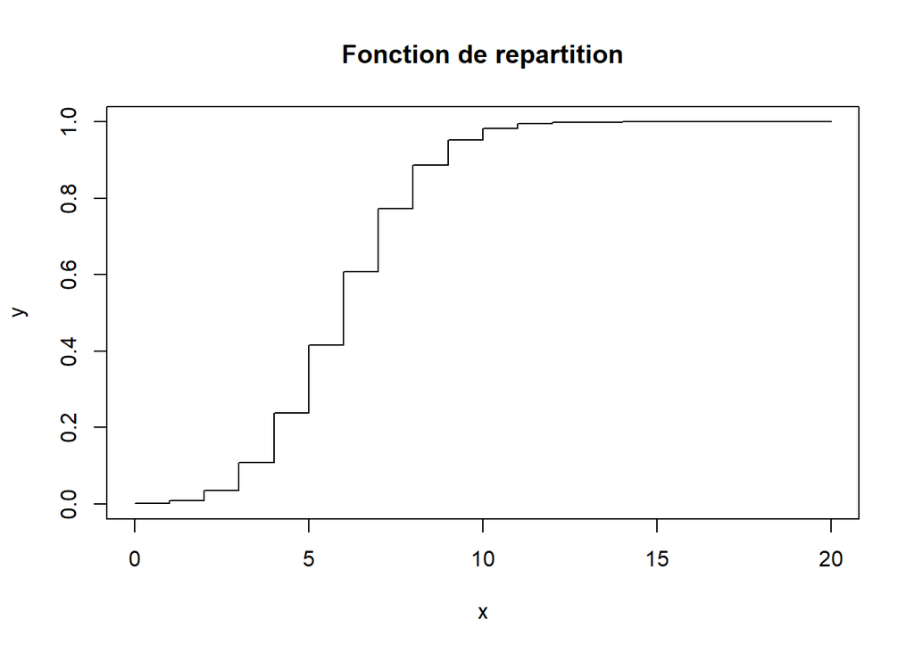

```r
y<-pbinom(x,n,p)
plot(x,y,main="Fonction de repartition",type="s")
```

```r
Med <- qbinom(0.5, n, p)
Q1 <- qbinom(0.25, n, p)
Q3 <- qbinom(0.75, n, p)
D1 <- qbinom(0.1, n, p)
D9 <- qbinom(0.9, n, p)
Id <- D9 - D1
```

### Exercice 2 Loi hypergéométrique

1. Affichez dans un diagramme en baton la loi H (100, 30, 10)

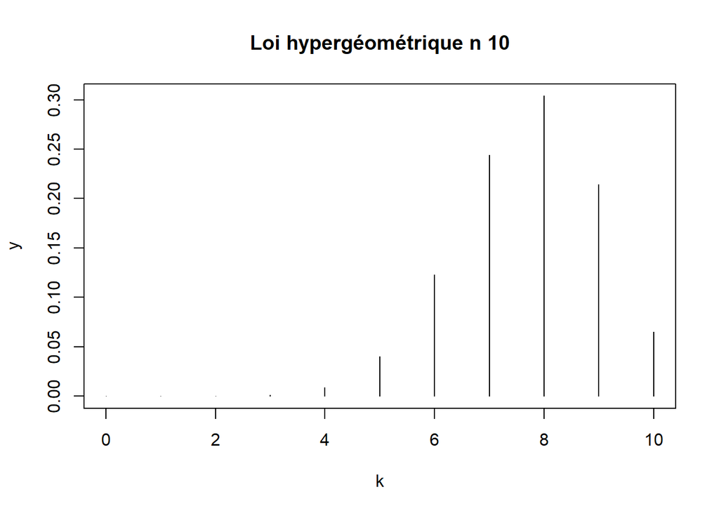

```r
N=100
K=30
n=10
k<-seq(0,n)
y<-dhyper(k,N,K,n)
 plot(k,y,type="h",main="Loi hypergéométrique n 10")
```

```r
y
```

```
##  [1] 1.127811e-07 5.370526e-06 1.087532e-04 1.235688e-03 8.739919e-03
##  [6] 4.027355e-02 1.226278e-01 2.439579e-01 3.038583e-01 2.142143e-01
## [11] 6.497833e-02
```

2. Quel est la médiane, Q1, Q3 ?

```r
Q1 <- qhyper(0.25, N, K, n)
Q3 <- qhyper(0.75, N, K, n)
Med <- qhyper(0.5, N, K, n)
Q1;Med;Q3
```

```
## [1] 7
```

```
## [1] 8
```

```
## [1] 9
```

3. Simulation : simulez l’expérience aléatoire 1000 fois et stockez les résultats dans un vecteur. Quelle est la moyenne, l’écart-type ?

```r
v<-rhyper(1000,N,K,n)
moy<-mean(v)
ecart<-sd(v)
moy;ecart
```

```
## [1] 7.649
```

```
## [1] 1.311304
```

4. Donnez un histogramme de la simulation

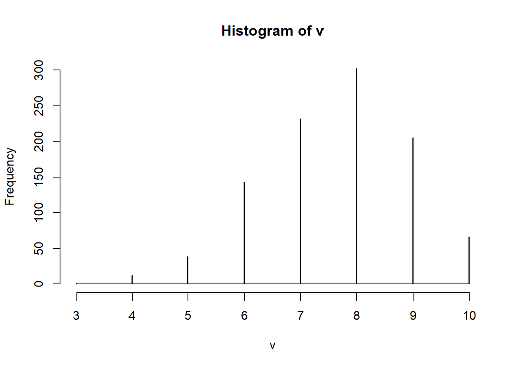

```r
hist(v, breaks = length(v))
```

5. Vérifier si l’on peut approcher les densités de la loi géométrique par une loi binomiale. Laquelle ?

### **Exercice 5 Loi de Poisson**

1. Dessinez la densité de probabilités d’une loi de Poisson de paramètre λ = 2

```r
x <- 0:10
lambda=2
P<-dpois(x,lambda)
P
```

```
##  [1] 1.353353e-01 2.706706e-01 2.706706e-01 1.804470e-01 9.022352e-02
##  [6] 3.608941e-02 1.202980e-02 3.437087e-03 8.592716e-04 1.909493e-04
## [11] 3.818985e-05
```

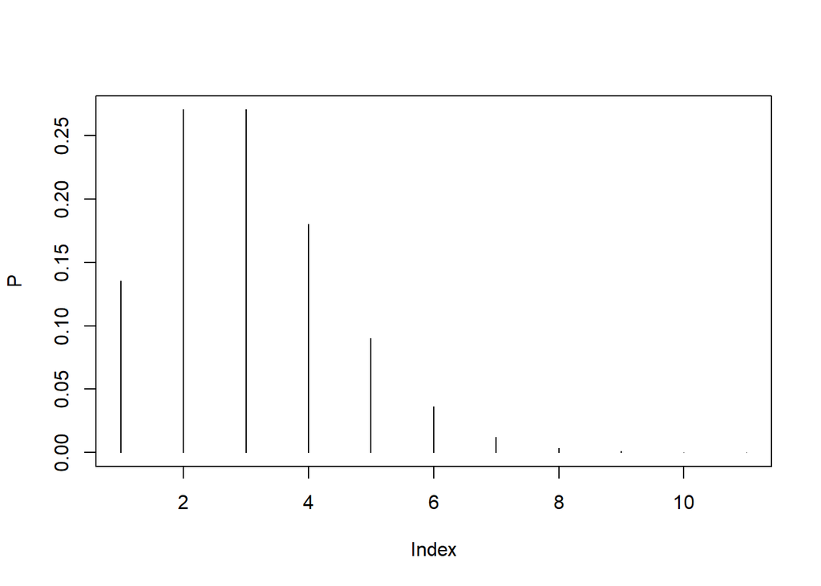

```r
plot(P,type="h")
```

2. Dessinez sa fonction de répartition

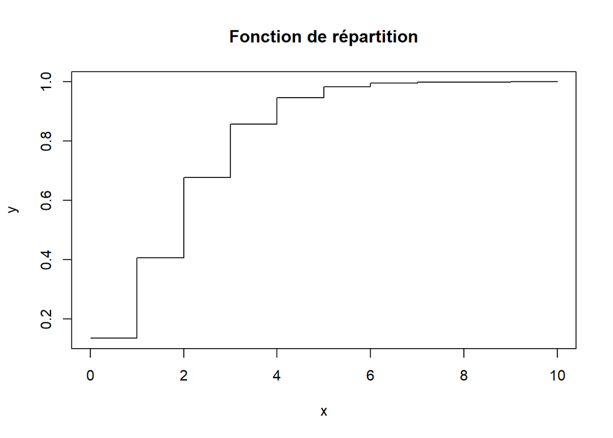

```r
y<-ppois(x,2)
plot(x,y,main = "Fonction de répartition", type="s")
```

3. Simulez 1000 tirages de la même loi et comparez la moyenne et l’écart-type mesurés par rapport aux valeurs théoriques

```r
v<-rpois(1000,2)
moy<-mean(v)
ecart<-sd(v)
moy;ecart
```

```
## [1] 1.98
```

```
## [1] 1.370941
```

```r
####################
moy2<-mean(P)
ecart2<-sd(P)
moy2;ecart2
```

```
## [1] 0.09090834
```

```
## [1] 0.1077471
```

4. Quelle est la médiane de la loi de Poisson ?

```r
Q1 <- qpois(0.25,2)
Q3 <- qpois(0.75,2)
Med <- qpois(0.5,2)
Q1;Med;Q3
```

```
## [1] 1
```

```
## [1] 2
```

```
## [1] 3
```

5. Pour X suivant une loi B(60, 0.05) calculez la probabilité P(X = 5) et comparez avec la valeur donnée par une loi de Poisson.

la probabilité P(X = 5)

```r
resultB<- dbinom(5,60,0.05)
resultB
```

```
## [1] 0.1016158
```

```r
resultP <- dpois(5,2)
resultP
```

```
## [1] 0.03608941
```

### Exercice 3 Poker

Lorsqu’on distribue 5 cartes à partir d’un paquet de 52 cartes, est-il plus probabble d’avoir un poker (n’importe lequel) ou une couleur (5 cartes de la même “couleur”) ?

Probabilite d’avoir 5 cartes de la même “couleur”

```r
choose(13,5)*4/choose(52,5)
```

```
## [1] 0.001980792
```

pour la poker (n’importe lequel),j ai pas compris Poker

### Exercice 4

Simuler l’extraction d’un échantillon La fonction sample(ensemble, n) permet d’échantillonner aléatoirement (par défaut sans remise) n éléments dans l’ensemble.

```r
couleur<-c("carreaux ","cœurs","trèfles","piques")
carte<-c("1","2","3","4","5","6","7","8","9","10","j","Q","K","A")
z<-apply(expand.grid(carte,couleur), 1, paste, collapse="_")
z
```

```
##  [1] "1_carreaux "  "2_carreaux "  "3_carreaux "  "4_carreaux "  "5_carreaux "
##  [6] "6_carreaux "  "7_carreaux "  "8_carreaux "  "9_carreaux "  "10_carreaux "
## [11] "j_carreaux "  "Q_carreaux "  "K_carreaux "  "A_carreaux "  "1_cœurs"
## [16] "2_cœurs"      "3_cœurs"      "4_cœurs"      "5_cœurs"      "6_cœurs"
## [21] "7_cœurs"      "8_cœurs"      "9_cœurs"      "10_cœurs"     "j_cœurs"
## [26] "Q_cœurs"      "K_cœurs"      "A_cœurs"      "1_trèfles"    "2_trèfles"
## [31] "3_trèfles"    "4_trèfles"    "5_trèfles"    "6_trèfles"    "7_trèfles"
## [36] "8_trèfles"    "9_trèfles"    "10_trèfles"   "j_trèfles"    "Q_trèfles"
## [41] "K_trèfles"    "A_trèfles"    "1_piques"     "2_piques"     "3_piques"
## [46] "4_piques"     "5_piques"     "6_piques"     "7_piques"     "8_piques"
## [51] "9_piques"     "10_piques"    "j_piques"     "Q_piques"     "K_piques"
## [56] "A_piques"
```

```r
sample(z, size = 5 )
```

```
## [1] "2_cœurs"     "3_carreaux " "9_cœurs"     "Q_piques"    "K_cœurs"
```